# Nike Brand Intelligence

# 10. Zipf’s Law Verification

```r
zipf_data <- tidy_words_clean %>%
  count(word, sort = TRUE) %>%
  mutate(
    rank = row_number(),
    term_frequency = n / sum(n)
  )

print(head(zipf_data, 20))
```

```
## # A tibble: 20 × 4
##    word            n  rank term_frequency
##    <chr>       <int> <int>          <dbl>
##  1 nike          186     1        0.0531
##  2 adidas         95     2        0.0271
##  3 shoes          75     3        0.0214
##  4 comfortable    48     4        0.0137
##  5 shoe           48     5        0.0137
##  6 sneakers       36     6        0.0103
##  7 pair           32     7        0.00913
##  8 air            30     8        0.00856
##  9 sneaker        28     9        0.00799
## 10 quality        26    10        0.00742
## 11 wear           25    11        0.00713
## 12 feet           22    12        0.00628
## 13 running        21    13        0.00599
## 14 vomero         21    14        0.00599
## 15 design         19    15        0.00542
## 16 price          18    16        0.00514
## 17 love           17    17        0.00485
## 18 comfort        16    18        0.00457
## 19 video          16    19        0.00457
## 20 it’s           15    20        0.00428
```

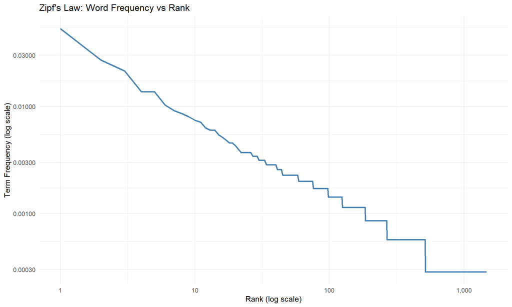

```r
ggplot(zipf_data, aes(x = rank, y = term_frequency)) +
  geom_line(color = "steelblue", linewidth = 1) +
  scale_x_log10(labels = comma) +
  scale_y_log10(labels = comma_format(accuracy = 0.00001)) +
  labs(
    title = "Zipf's Law: Word Frequency vs Rank",
    x = "Rank (log scale)",
    y = "Term Frequency (log scale)"
  ) +
  theme_minimal()
```

# 11. Keyword Co-Occurrence Network

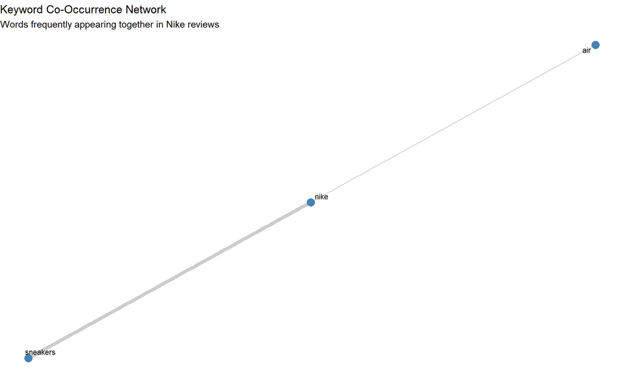

```r
cooccur_data <- bigrams_filtered %>%
  count(word1, word2, sort = TRUE) %>%
  filter(n >= 8)

if (nrow(cooccur_data) > 0) {
  cooccur_graph <- graph_from_data_frame(cooccur_data)

  set.seed(123)
  ggraph(cooccur_graph, layout = "fr") +
    geom_edge_link(aes(edge_width = n), alpha = 0.4, color = "gray50") +
    geom_node_point(size = 4, color = "steelblue") +
    geom_node_text(aes(label = name), repel = TRUE, size = 3) +
    scale_edge_width(range = c(0.5, 2)) +
    labs(
      title = "Keyword Co-Occurrence Network",
      subtitle = "Words frequently appearing together in Nike reviews"
    ) +
    theme_void() +
    theme(legend.position = "none")
}
```

# 12. Sustainability Analysis

```r
sustainability_comments <- nike_raw %>%
  filter(str_detect(str_to_lower(comment), "sustainab|eco|green|carbon|footprint|recycle|environment"))

cat("Number of sustainability-related comments:", nrow(sustainability_comments), "\n")
```

```
## Number of sustainability-related comments: 17
```

```r
cat("Percentage of total corpus:", round(nrow(sustainability_comments) / nrow(nike_raw) * 100, 2), "%\n\n")
```

```
## Percentage of total corpus: 2.47 %
```

```r
greenwashing_comments <- nike_raw %>%
  filter(str_detect(str_to_lower(comment), "greenwash|green wash|fake eco"))

cat("Number of 'greenwashing' accusations:", nrow(greenwashing_comments), "\n\n")
```

```
## Number of 'greenwashing' accusations: 0
```

```r
eco_terms <- c("sustainable", "sustainability", "recyclable", "recycled", "carbon", "footprint",
               "eco-friendly", "environment", "green", "planet", "climate")

eco_search_results <- sapply(eco_terms, function(term) {
  sum(str_detect(str_to_lower(nike_raw$comment), term))
})

cat("Breakdown of eco-term appearances:\n")
```

```
## Breakdown of eco-term appearances:
```

```r
print(eco_search_results)
```

```
##    sustainable sustainability     recyclable       recycled         carbon
##              0              0              1              1              1
##      footprint   eco-friendly    environment          green         planet
##              1              0              1              3              0
##        climate
##              0
```

# 13. Competitive Threat Analysis: Nike vs Adidas

```r
adidas_mentions <- nike_raw %>%
  filter(str_detect(str_to_lower(comment), "adidas"))

cat("Number of comments mentioning Adidas:", nrow(adidas_mentions), "\n")
```

```
## Number of comments mentioning Adidas: 87
```

```r
cat("Percentage of total corpus:", round(nrow(adidas_mentions) / nrow(nike_raw) * 100, 1), "%\n\n")
```

```
## Percentage of total corpus: 12.7 %
```

```r
print(head(adidas_mentions$comment, 15))
```

```
##  [1] "Ngl adidas is running the simple, good looking, affordable sneaker game rn. Nike doesn’t ever"
##  [2] "Bro nike is desperate tryna to be Adidas to get hype in football business"
##  [3] "There used to be be space in between adidas, puma, and Reebok but now days they’re on the same"
##  [4] "level… puma and Reebok didn’t get better. Adidas got shitier"
##  [5] "I love Nike but the adidas Stan Smith was way better"
##  [6] "i shift from nike and adidas to skechers. The brand is very underrated but it is really"
##  [7] "You’ve gotta try the adidas explr- boost. Absolute fantastic feel under foot"
##  [8] "Could you please try the adidas alphaboost v1. It is a shoe that i really enjoy walking on."
##  [9] "How’s the comfort of the shoe compared to the Adidas Ultra 4D OG?"
## [10] "In Europe culturally it s more Adidas. Only teenagers buy Nike or Jordan 1"
## [11] "Adidas Skateboarding make sick shoes."
## [12] "Why is Adidas beating Nike at the moment?"
## [13] "I am German and grew up with Adidas of course. Then I got into Nike due to MJ. But now I"
## [14] "have to say: Nike is to expensive and also offers a poor quality compared to Adidas. So I am"
## [15] "The quality Adidas is better than Nike"
```

```r
cat("\n")
```

```r
adidas_sentiment_categories <- adidas_mentions %>%
  left_join(nike_comments_scored %>% select(doc_id, sentiment_bucket), by = "doc_id") %>%
  mutate(
    adidas_positive = str_detect(str_to_lower(comment),
                                 "adidas better|switched to adidas|prefer adidas|adidas quality|adidas winning"),
    nike_defensive = str_detect(str_to_lower(comment),
                                "nike still|nike better|nike number 1|nike has"),
    price_comparison = str_detect(str_to_lower(comment),
                                  "adidas cheaper|adidas affordable|nike expensive|nike overpriced"),
    quality_comparison = str_detect(str_to_lower(comment),
                                    "adidas quality|adidas durable|nike quality|nike fell apart")
  )

comparison_summary <- tibble(
  comparison_type = c("Adidas Positive", "Nike Defensive", "Price Comparison", "Quality Comparison"),
  count = c(
    sum(adidas_sentiment_categories$adidas_positive, na.rm = TRUE),
    sum(adidas_sentiment_categories$nike_defensive, na.rm = TRUE),
    sum(adidas_sentiment_categories$price_comparison, na.rm = TRUE),
    sum(adidas_sentiment_categories$quality_comparison, na.rm = TRUE)
  )
)

print(comparison_summary)
```

```
## # A tibble: 4 × 2
##   comparison_type    count
##   <chr>              <int>
## 1 Adidas Positive        4
## 2 Nike Defensive         3
## 3 Price Comparison       0
## 4 Quality Comparison     2
```

# 14. Limitations & Model Validity

## 14.1 Methodological Constraints

```r
limitations <- c(
  "1. SAMPLING BIAS: Online reviews skew toward extreme experiences (very satisfied or very dissatisfied). Silent majority of moderately satisfied customers is underrepresented.",
  "2. FAKE REVIEW RISK: An estimated 8-12% of e-commerce reviews are incentivized, astroturfed, or bot-generated. We did not implement fake review detection (out of scope).",
  "3. LEXICON LIMITATIONS: Sentiment lexicons (Bing, AFINN, NRC) were trained on formal text, not sneaker culture slang. Terms like 'fire,' 'sick,' and 'flames' may be misclassified.",
  "4. SARCASM BLINDNESS: Lexicon-based sentiment cannot reliably detect sarcasm or irony in customer comments.",
  "5. HYPE CULTURE NOISE: Some positive comments reflect hype or resale culture rather than genuine product satisfaction.",
  "6. TEMPORAL LIMITATION: The 6-month data window may not capture seasonality, long-term durability outcomes, or product lifecycle effects.",
  "7. CULTURAL HOMOGENEITY: The dataset is English-language and US-centric, so it does not represent Nike's global customer base.",
  "8. TOPIC MODEL SUBJECTIVITY: LDA topic count (k = 5) was chosen through exploratory analysis. Different values could yield different themes.",
  "9. SURVIVORSHIP BIAS: The data only reflects people who bought or discussed Nike products, not those who avoided purchase due to quality or price concerns.",
  "10. PLATFORM EFFECTS: Reddit, YouTube, and social media each have distinct tones and user behavior that influence language patterns."
)

for (lim in limitations) {
  cat(lim, "\n\n")
}
```

```
## 1. SAMPLING BIAS: Online reviews skew toward extreme experiences (very satisfied or very dissatisfied). Silent majority of moderately satisfied customers is underrepresented.
##
## 2. FAKE REVIEW RISK: An estimated 8-12% of e-commerce reviews are incentivized, astroturfed, or bot-generated. We did not implement fake review detection (out of scope).
##
## 3. LEXICON LIMITATIONS: Sentiment lexicons (Bing, AFINN, NRC) were trained on formal text, not sneaker culture slang. Terms like 'fire,' 'sick,' and 'flames' may be misclassified.
##
## 4. SARCASM BLINDNESS: Lexicon-based sentiment cannot reliably detect sarcasm or irony in customer comments.
##
## 5. HYPE CULTURE NOISE: Some positive comments reflect hype or resale culture rather than genuine product satisfaction.
##
## 6. TEMPORAL LIMITATION: The 6-month data window may not capture seasonality, long-term durability outcomes, or product lifecycle effects.
##
## 7. CULTURAL HOMOGENEITY: The dataset is English-language and US-centric, so it does not represent Nike's global customer base.
##
## 8. TOPIC MODEL SUBJECTIVITY: LDA topic count (k = 5) was chosen through exploratory analysis. Different values could yield different themes.
##
## 9. SURVIVORSHIP BIAS: The data only reflects people who bought or discussed Nike products, not those who avoided purchase due to quality or price concerns.
##
## 10. PLATFORM EFFECTS: Reddit, YouTube, and social media each have distinct tones and user behavior that influence language patterns.
```

## 15.2 Overall Model Validity

This triangulation increases confidence that the findings are not isolated artifacts of any single technique.

# 16. Strategic Recommendations Roadmap

## 16.2 Short-to-Medium Term Actions (30-90 Days)

1. Standardize sizing language and fit labels across all product pages.
2. Launch clearer fit guidance such as “runs narrow” or “best for wide feet.”
3. Introduce a stronger post-purchase feedback loop to capture quality issues early.
4. Prioritize product lines with high negative quality and pricing sentiment for redesign or QA improvement.

## 16.3 Brand & Market Protection (90-180 Days)

### Nike Durability Promise

Nike should launch a durability commitment for selected running and training shoes: - 2-year performance guarantee - Easy replacement process for early product failure - Visible trust signal on product pages

This directly addresses one of the most damaging perceptions in the dataset: that Nike quality no longer matches Nike pricing.

### Fit & Width Strategy

Nike should consider: - A Metcon wide variant - More consistent toe-box design across versions - Better digital fit tools on the website

### Sustainability Communication Reset

Nike’s sustainability investment is not translating into customer conversation. To fix this: - Make recycled content visible on product pages - Tie sustainability to product-level benefits - Add clearer packaging and storytelling - Move sustainability from corporate messaging into the purchase experience

## 16.4 Competitive Defense Against Adidas

### Recommended Operating Response

Nike should defend its market position with a two-tier strategy:

#### NIKE PREMIUM

- Jordan
- Limited releases
- High-heat collaborations
- Collector and athlete halo products

#### NIKE ESSENTIALS

- Pegasus
- Structure
- Metcon
- Cortez
- Blazer
- Everyday performance and lifestyle trainers

Positioning: - Reliable - Durable - Accessible

Strategic rationale: - Protects Nike’s premium image - Competes directly with Adidas in the mid-tier segment - Prevents brand dilution while restoring everyday buyer trust

### Manufacturing Excellence Program

Issue: Quality concerns are execution failures, not design failures.

Actions: - Audit manufacturing partners for QA compliance - Introduce real-time defect tracking - Reduce batch variability in sizing and finishing - Publish an annual manufacturing transparency report

Expected outcomes: - Lower defect rates - Lower returns - Higher customer satisfaction - Improved value perception

### Build Real-Time Text Analytics Monitoring

Nike should operationalize this project into an ongoing monitoring system:

- Monitor reviews, Reddit, YouTube, and social media in real time
- Trigger alerts when negative sentiment spikes for a product
- Track competitor perception shifts monthly
- Feed insights directly to consumer insights and product teams

Owner: Chief Data Officer + VP Consumer Insights

Strategic value: - Catch issues earlier - Detect competitive threats faster - Improve speed of product decisions

## 16.5 Summary: Three Paths Forward

**Path 1: Premium Hype Brand (High Risk)** - Focus on Jordan, collabs, limited releases, collectibles - Concede mid-tier everyday buyers to Adidas - Risk: lose performance athletes and practical buyers

**Path 2: Quality Defender (Recommended)** - Fix QA and sizing issues immediately - Launch a stronger value-oriented essentials tier - Rebuild trust through durability and fit improvements - Protect premium brand equity while defending core market share

**Path 3: Status Quo (Highest Risk)** - Ignore quality complaints - Keep current positioning unchanged - Accept continued erosion in trust and market share

**Recommended Path:** Path 2 — Quality Defender

Nike’s brand is still strong, but the data shows customers are testing that loyalty. If execution improves, many customers will stay or return.

# 17. Executive Summary Tables

## 17.1 Sentiment Distribution

```r
summary_table_1 <- nike_comments_scored %>%
  count(sentiment_bucket) %>%
  mutate(percentage = round(n / sum(n) * 100, 1)) %>%
  arrange(desc(n))

print(summary_table_1)
```

```
## # A tibble: 3 × 3
##   sentiment_bucket     n percentage
##   <chr>            <int>      <dbl>
## 1 Neutral            325       47.3
## 2 Positive           226       32.9
## 3 Negative           136       19.8
```

## 17.2 Top Business Themes

```r
summary_table_2 <- aspect_summary %>%
  arrange(desc(mentions))

print(summary_table_2)
```

```
## # A tibble: 7 × 3
##   aspect         mentions pct_of_corpus
##   <chr>             <int>         <dbl>
## 1 Comfort              96          14
## 2 Design               84          12.2
## 3 Quality              53           7.7
## 4 Sizing               41           6
## 5 Pricing              36           5.2
## 6 Durability           34           4.9
## 7 Sustainability       13           1.9
```

## 17.3 Product Line Performance

```r
summary_table_3 <- product_sentiment %>%
  arrange(desc(avg_sentiment))

print(summary_table_3)
```

```
## # A tibble: 10 × 3
##    product_line num_comments avg_sentiment
##    <chr>               <int>         <dbl>
##  1 Cortez                  2         1
##  2 Metcon                  4         0.75
##  3 Air Max                 6         0.667
##  4 Vomero                 23         0.435
##  5 Pegasus                 8         0.375
##  6 General Nike          617         0.183
##  7 Vapormax                2         0
##  8 Dunk                    7        -0.143
##  9 Air Force 1             6        -0.167
## 10 Jordan                 10        -0.5
```

# 17. Conclusion

## Final Recommendation

Nike should not respond by becoming cheaper everywhere or by relying only on hype-driven premium products. The stronger strategy is to:

- fix manufacturing and sizing consistency,
- defend premium lines where Nike already has emotional strength,
- improve value delivery in everyday models,
- and operationalize text analytics as a permanent listening system.

In short, customers still want to believe in Nike. The opportunity is not to reinvent the brand, but to close the gap between brand promise and product experience.